# R Notebook

## UK Productivity Predictor

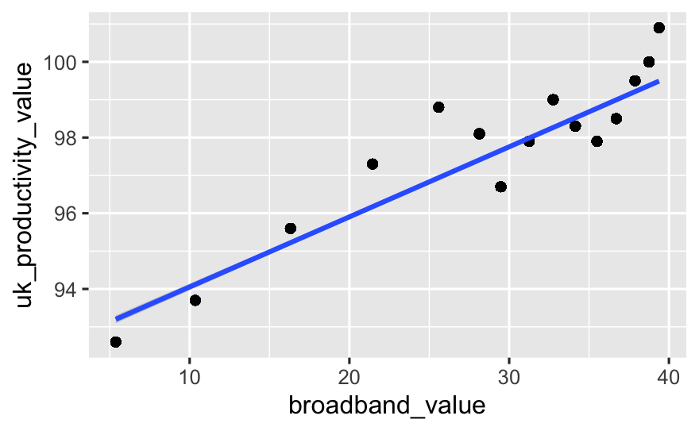

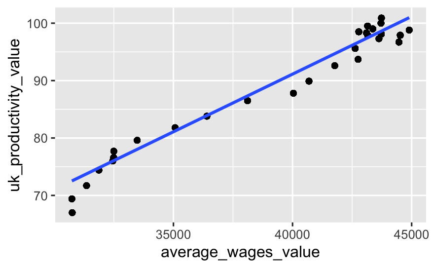

We already knew this

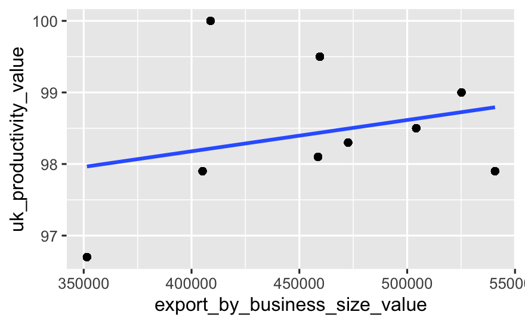

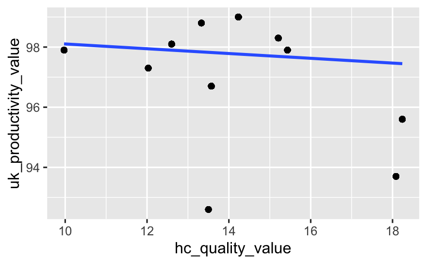

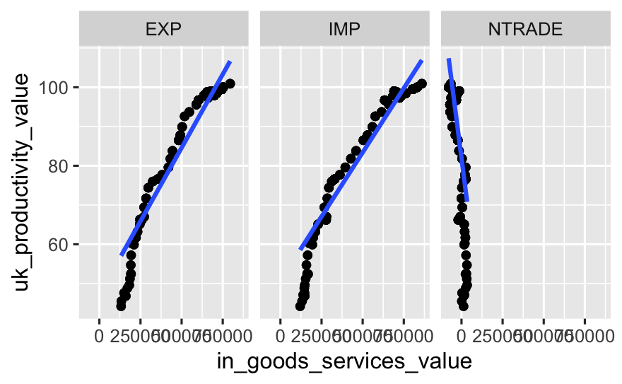

Exports looks the most promising of the 3

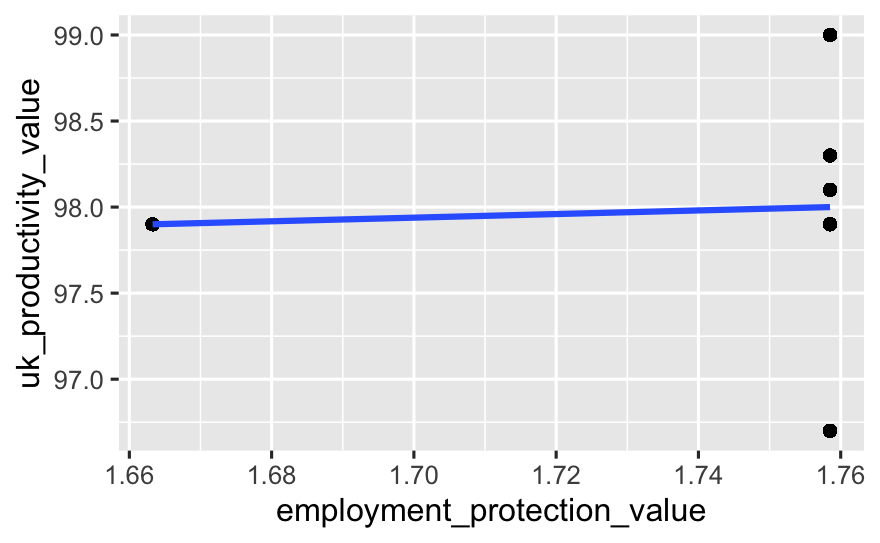

Not enough data

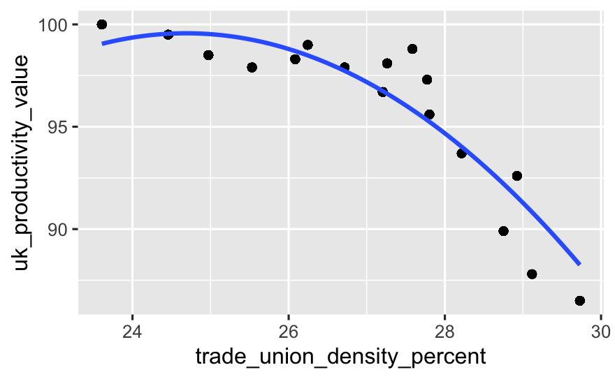

From this investigation and what we already know, the following measures will be used to predict uk productivity: -exports value -average wages value -broadband value -infrastructure investment per population -adult_education_level_value -research and development investment per population -trade union density

```r
summary(uk_model_data)
```

```
     time           uk_productivity_value average_wages_value
 Length:48          Min.   : 44.20        Min.   :30736
 Class :character   1st Qu.: 58.55        1st Qu.:33232
 Mode  :character   Median : 76.00        Median :42201
                    Mean   : 75.05        Mean   :39191
                    3rd Qu.: 96.15        3rd Qu.:43434
                    Max.   :100.90        Max.   :44897
                    NA's   :1             NA's   :20
 broadband_value  r_d_research_value adult_education_level_value
 Min.   : 5.375   Min.   :24713      Min.   :22.56
 1st Qu.:23.520   1st Qu.:28047      1st Qu.:26.84
 Median :31.251   Median :31048      Median :35.22
 Mean   :28.205   Mean   :32291      Mean   :34.15
 3rd Qu.:36.102   3rd Qu.:37369      3rd Qu.:40.98
 Max.   :39.383   Max.   :42949      Max.   :45.77
 NA's   :33       NA's   :14         NA's   :27
 total_investment      population       in_goods_services_value
 Min.   :8.539e+09   Min.   :55663250   Min.   :123593
 1st Qu.:1.220e+10   1st Qu.:56328190   1st Qu.:192958
 Median :1.343e+10   Median :57792180   Median :311237
 Mean   :1.379e+10   Mean   :58860926   Mean   :389022
 3rd Qu.:1.442e+10   3rd Qu.:60512610   3rd Qu.:593017
 Max.   :2.340e+10   Max.   :66058859   Max.   :794926
 NA's   :26
 trade_union_density_percent rd_invest_per_pop  infra_invest_per_pop
 Min.   :23.61               Min.   :0.000439   Min.   :147.2
 1st Qu.:26.08               1st Qu.:0.000488   1st Qu.:203.7
 Median :27.26               Median :0.000528   Median :222.2
 Mean   :27.06               Mean   :0.000538   Mean   :224.1
 3rd Qu.:28.22               3rd Qu.:0.000597   3rd Qu.:236.5
 Max.   :29.73               Max.   :0.000655   Max.   :359.3
 NA's   :31                  NA's   :14         NA's   :26
```

## Multi-linear regression

```r
summary(uk_productivity_multi_lin_model)
```

```
Call:
lm(formula = uk_productivity_value ~ average_wages_value + broadband_value +
    adult_education_level_value + rd_invest_per_pop + infra_invest_per_pop +
    trade_union_density_percent + in_goods_services_value, data = uk_model_data_complete)

Residuals:
     Min       1Q   Median       3Q      Max
-0.55555 -0.23065  0.05069  0.16282  0.75150

Coefficients:
                              Estimate Std. Error t value Pr(>|t|)
(Intercept)                  5.658e+01  1.612e+01   3.509   0.0127 *
average_wages_value          5.248e-04  3.014e-04   1.741   0.1323
broadband_value              8.568e-02  8.646e-02   0.991   0.3600
adult_education_level_value -1.554e-01  1.637e-01  -0.950   0.3790
rd_invest_per_pop            6.832e+03  1.694e+04   0.403   0.7008
infra_invest_per_pop        -1.919e-03  7.962e-03  -0.241   0.8176
trade_union_density_percent  3.667e-02  4.755e-01   0.077   0.9410
in_goods_services_value      2.587e-05  6.638e-06   3.898   0.0080 **
---
Signif. codes:  0 ‘***’ 0.001 ‘**’ 0.01 ‘*’ 0.05 ‘.’ 0.1 ‘ ’ 1

Residual standard error: 0.4897 on 6 degrees of freedom
Multiple R-squared:  0.9757,    Adjusted R-squared:  0.9473
F-statistic: 34.38 on 7 and 6 DF,  p-value: 0.0001984
```

| term | estimate | std_error | statistic | p_value |
| --- | --- | --- | --- | --- |
| (Intercept) | 5.657736e+01 | 1.612339e+01 | 3.50902321 | 0.012686454 |
| average_wages_value | 5.248391e-04 | 3.014059e-04 | 1.74130352 | 0.132271772 |
| broadband_value | 8.567640e-02 | 8.645826e-02 | 0.99095671 | 0.359971828 |
| adult_education_level_value | -1.554143e-01 | 1.636655e-01 | -0.94958519 | 0.378986685 |
| rd_invest_per_pop | 6.831597e+03 | 1.694402e+04 | 0.40318629 | 0.700785472 |
| infra_invest_per_pop | -1.918541e-03 | 7.962230e-03 | -0.24095517 | 0.817612494 |
| trade_union_density_percent | 3.667166e-02 | 4.754766e-01 | 0.07712611 | 0.941030812 |
| in_goods_services_value | 2.587225e-05 | 6.637765e-06 | 3.89773576 | 0.008004871 |

As I have concerns about the size of the data set I will use K-fold validation to confirm the results

| time | uk_productivity_value | average_wages_value | broadband_value | r_d_research_value | adult_education_level_value | total_investment | population | in_goods_services_value | trade_union_density_percent | rd_invest_per_pop | infra_invest_per_pop |
| --- | --- | --- | --- | --- | --- | --- | --- | --- | --- | --- | --- |
| 2008 | 98.1 | 43724.12 | 28.137 | 37684.49 | 35.21617 | 13574897677 | 61806995 | 657209.8 | 27.26158 | 0.0006097123 | 219.6337 |
| 2009 | 96.7 | 44464.95 | 29.480 | 37441.73 | 36.98496 | 12873755869 | 62276270 | 602514.0 | 27.20427 | 0.0006012198 | 206.7201 |
| 2010 | 97.9 | 44520.53 | 31.251 | 37573.30 | 38.18719 | 12870017479 | 62766365 | 636604.8 | 26.71742 | 0.0005986216 | 205.0464 |
| 2011 | 99.0 | 43369.94 | 32.753 | 38254.46 | 39.41237 | 13097682646 | 63258810 | 677618.9 | 26.24454 | 0.0006047293 | 207.0491 |
| 2012 | 98.3 | 43105.08 | 34.144 | 37151.48 | 40.97775 | 14323368265 | 63700215 | 686974.8 | 26.08374 | 0.0005832237 | 224.8559 |
| 2013 | 97.9 | 43153.99 | 35.498 | 38980.64 | 41.89198 | 14456302402 | 64128273 | 697356.4 | 25.53106 | 0.0006078542 | 225.4279 |
| 2014 | 98.5 | 42781.91 | 36.705 | 40612.03 | 42.21745 | 17939807788 | 64602298 | 713273.3 | 24.97339 | 0.0006286469 | 277.6961 |
| 2015 | 99.5 | 43152.17 | 37.879 | 41783.63 | 44.19799 | 23395267217 | 65116219 | 744938.4 | 24.45823 | 0.0006416778 | 359.2848 |
| 2005 | 95.6 | 42630.47 | 16.313 | 34626.46 | 29.70903 | 14325193742 | 60401206 | 589851.2 | 27.80335 | 0.0005732744 | 237.1673 |
| 2016 | 100.0 | 43712.62 | 38.761 | 42949.15 | 45.76676 | 22186425693 | 65611593 | 752686.0 | 23.60775 | 0.0006545969 | 338.1480 |

[output cut: 4 more lines]

```r
mean(uk_productivity_multi_lin_model_cv$resample$RMSE)
```

```
[1] 0.5819183
```

```r
mean(uk_productivity_multi_lin_model_cv$resample$Rsquared)
```

```
[1] NA
```

The diagnotic plots for this model again isn’t ideal

[figure not shown]

```r
par(mfrow = c(2, 2))
plot(uk_productivity_multi_lin_model)
```